# TAREFA 4 Análise de Tópicos com LDA em Resenhas de Filmes (IMDB) - Análise Multivariada

Márcia Barbian

```r
# install.packages(c("tidytext", "textdata", "dplyr", "ggplot2", "tm", "topicmodels", "textclean"))

library(tidytext)
library(textdata)
library(dplyr)
library(ggplot2)
library(tm)
library(topicmodels)
library(textclean)
library(readr)
library(stringr)
library(janeaustenr)
library(stm)
library(wordcloud)
library(MCMCpack)
library(tidyverse)

set.seed(42)
```

## Objetivo

Este exercício tem como objetivo identificar **tópicos latentes** em resenhas de filmes utilizando o modelo **LDA (Latent Dirichlet Allocation)** com dados reais da base IMDB. O banco de dados está disponível no link: http://ai.stanford.edu/~amaas/data/sentiment/aclImdb_v1.tar.gz Descompacte esse arquivo e coloque a pasta aclImdb na mesma pasta do projeto da tarefa 4.

OBS: A base é muito grande, então você deve escolher um parte dela.

Antes de fazer o exerício veja os vídeos: https://www.youtube.com/watch?v=T05t-SqKArY&t=1473s e https://www.youtube.com/watch?v=BaM1uiCpj_E

Veja o livro: https://www.tidytextmining.com/

```r
# Carregar base IMDB reduzida (1000 exemplos)

path_pos <- "aclImdb/train/pos"
path_neg <- "aclImdb/train/neg"

# Listar os arquivos .txt
files_pos <- list.files(path_pos, full.names = TRUE)
files_neg <- list.files(path_neg, full.names = TRUE)

head(files_pos)
```

```
## [1] "aclImdb/train/pos/0_9.txt"     "aclImdb/train/pos/1_7.txt"
## [3] "aclImdb/train/pos/10_9.txt"    "aclImdb/train/pos/100_7.txt"
## [5] "aclImdb/train/pos/1000_8.txt"  "aclImdb/train/pos/10000_8.txt"
```

```r
files_pos_amostra = files_pos[sample(1:length(files_pos), 500)]
files_neg_amostra  = files_neg[sample(1:length(files_neg), 500)]

# Ler os textos
pos_reviews <- sapply(files_pos_amostra, read_file)
neg_reviews <- sapply(files_neg_amostra, read_file)

# Montar data frame com rótulo
imdb <- data.frame(
  review = c(pos_reviews, neg_reviews),
  sentiment = c(rep("pos", length(pos_reviews)), rep("neg", length(neg_reviews))),
  stringsAsFactors = FALSE
)

# Visualizar
head(imdb)
```

```
##                                                                                                                                                                                                                                                                                                          …
## aclImdb/train/pos/8469_7.txt                                                                                                                                                                                                                                                                             …
## aclImdb/train/pos/9783_9.txt                                                                                                                                                          How you could say that Peaches, with its complex narrative dealing with a multitude of issues, is "a small TV idea"…
## aclImdb/train/pos/12128_8.txt  I just saw "Of Human Bondage" for the first time a few days ago and WOW! What a mysterious and almost spooky film. I loved how the music went with the pace of each step of Philip's feet. It gave me the chills for some reason...<br /><br />One of the greatest aspects…
## aclImdb/train/pos/3493_8.txt                                                                                                                                                                                                                                                                             …
## aclImdb/train/pos/7108_9.txt                                                                                                                                                                                                                                                                             …
## aclImdb/train/pos/11122_10.txt                                                                                                                                                                                                                                                                           …
##                                sentiment
## aclImdb/train/pos/8469_7.txt         pos
## aclImdb/train/pos/9783_9.txt         pos
## aclImdb/train/pos/12128_8.txt        pos
## aclImdb/train/pos/3493_8.txt         pos
## aclImdb/train/pos/7108_9.txt         pos
## aclImdb/train/pos/11122_10.txt       pos
```

```r
# Substituir contrações e símbolos
imdb$review <- replace_contraction(imdb$review)
imdb$review <- replace_symbol(imdb$review)

# Criar corpus e limpar
corpus <- Corpus(VectorSource(imdb$review))
corpus <- tm_map(corpus, content_transformer(tolower))
corpus <- tm_map(corpus, removePunctuation)
corpus <- tm_map(corpus, removeNumbers)
corpus <- tm_map(corpus, removeWords, stopwords("en"))
corpus <- tm_map(corpus, stripWhitespace)

# Matriz documento-termo
dtm <- DocumentTermMatrix(corpus)
dtm <- removeSparseTerms(dtm, 0.99)
dtm
```

```
## <<DocumentTermMatrix (documents: 1000, terms: 1547)>>
## Non-/sparse entries: 59853/1487147
## Sparsity           : 96%
## Maximal term length: 14
## Weighting          : term frequency (tf)
```

## Palavras mais frequentes

```r
# Transformar em tibble para tidytext
reviews_tbl <- tibble(document = 1:length(imdb$review), text = imdb$review)

# Tokenizar, remover stopwords e contar frequências
word_freq <- reviews_tbl %>%
  unnest_tokens(word, text) %>%
  filter(!word %in% stop_words$word,
         str_detect(word, "^[a-z']+$")) %>%
  count(word, sort = TRUE)

# Mostrar top 15 palavras
head(word_freq, 15)
```

```
## # A tibble: 15 × 2
##    word           n
##    <chr>      <int>
##  1 br          3730
##  2 movie       1717
##  3 film        1592
##  4 time         517
##  5 story        462
##  6 people       336
##  7 bad          335
##  8 characters   309
##  9 movies       300
## 10 watch        299
## 11 plot         296
## 12 films        283
## 13 character    261
## 14 life         249
## 15 acting       248
```

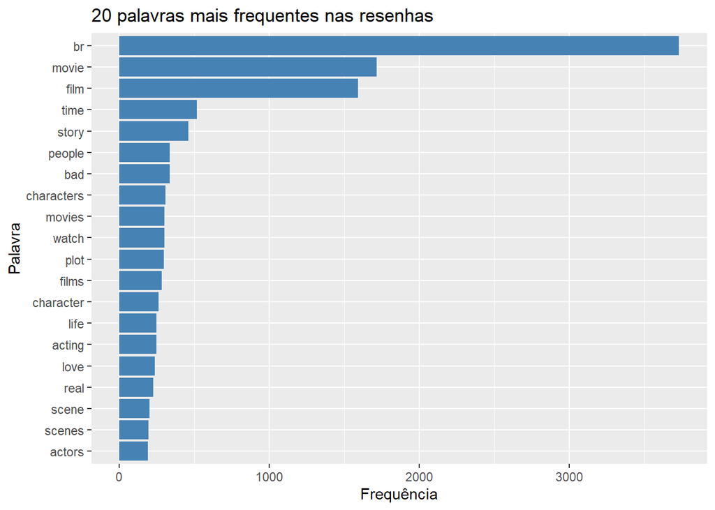

```r
# Gráfico das 20 palavras mais frequentes
word_freq %>%
  top_n(20, n) %>%
  mutate(word = reorder(word, n)) %>%
  ggplot(aes(word, n)) +
  geom_col(fill = "steelblue") +
  coord_flip() +
  labs(title = "20 palavras mais frequentes nas resenhas",
       x = "Palavra", y = "Frequência")
```

# Questões

## Questão 1

### 1a) Algum tópico parece estar relacionado a emoção ou julgamento dos filmes? (ex: *great*, *bad*, *boring*). Quais palavras caracterizam cada um dos 4 tópicos? Dê um título para cada um. Dica: faça uma nuvem de palavras para cada tópico.

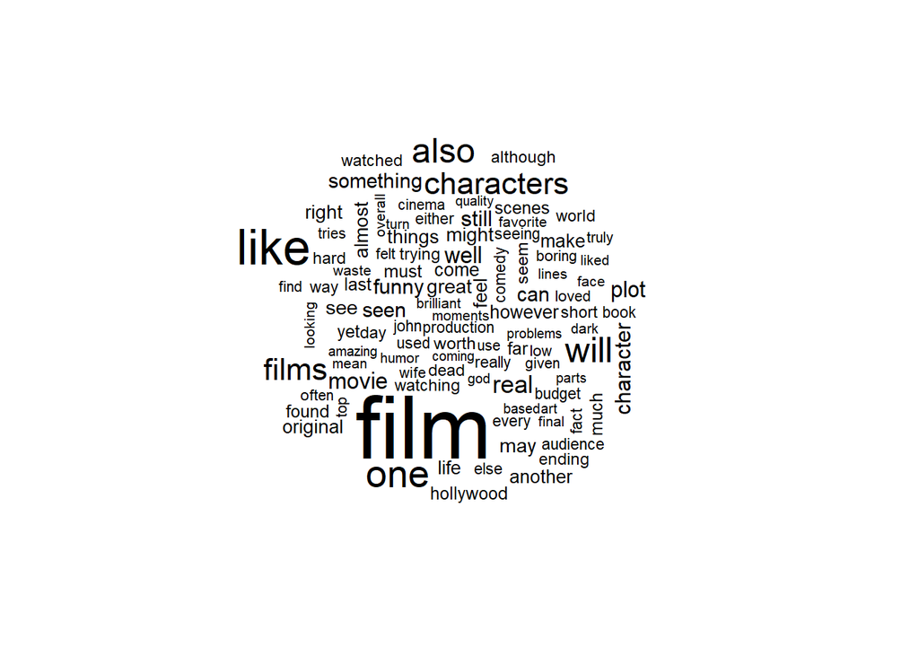

```r
dfm <- tidy(dtm) %>%
  cast_dfm(document = document,
           term = term,
           value = count)

lda4 <- stm(dfm,
            K = 4,
            verbose = FALSE,
            init.type = "LDA",
            seed = 42)

cloud(lda4, 1)
```

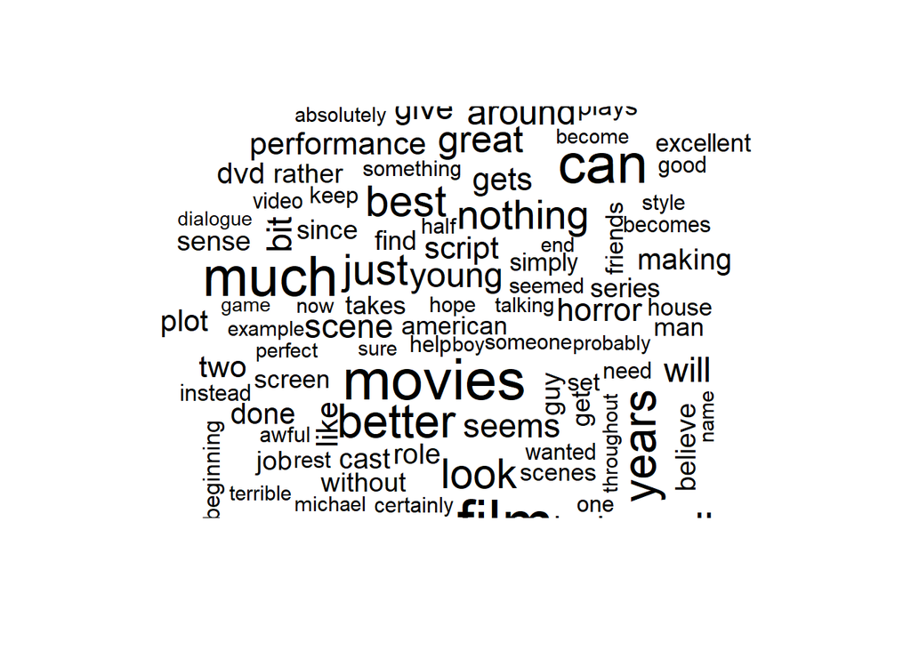

```r
cloud(lda4, 2)
```

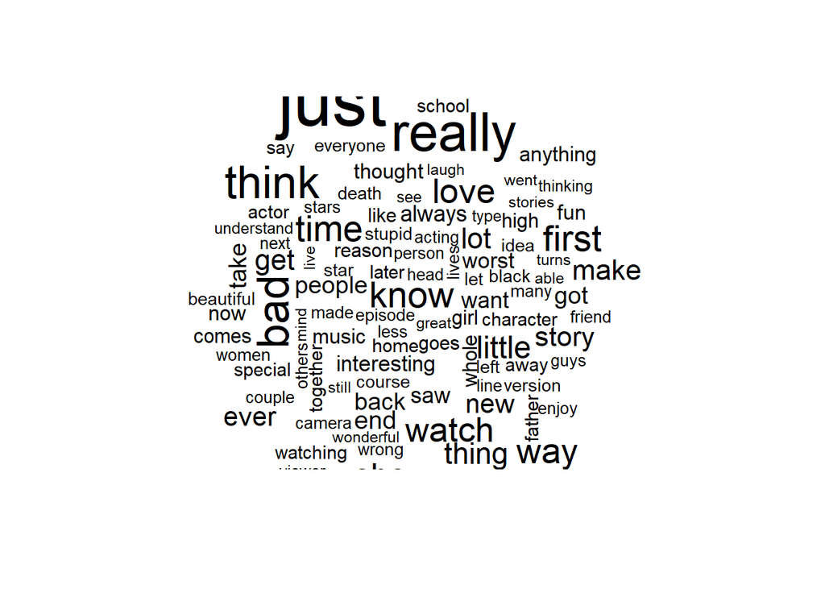

```r
cloud(lda4, 3)
```

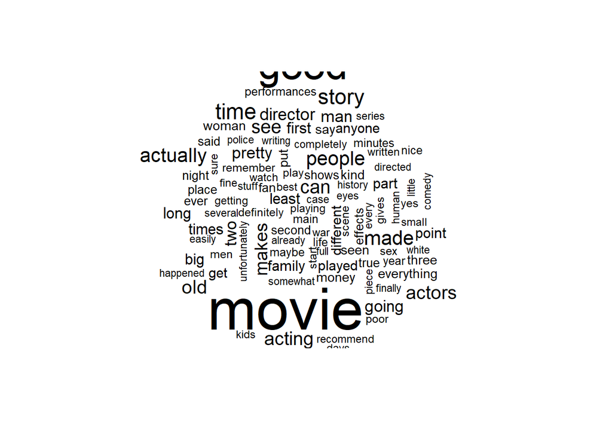

```r
cloud(lda4, 4)
```

```r
summary(lda4)
```

```
## A topic model with 4 topics, 1000 documents and a 1547 word dictionary.
```

```
## Topic 1 Top Words:
##       Highest Prob: film, like, one, will, also, films, characters
##       FREX: also, films, real, funny, may, original, might
##       Lift: beach, films, also, real, original, hollywood, might
##       Score: film, also, films, like, will, characters, real
## Topic 2 Top Words:
##       Highest Prob: even, film, movies, can, much, better, many
##       FREX: better, work, look, young, nothing, seems, bit
##       Lift: harry, better, young, work, look, seems, horror
##       Score: even, better, movies, work, look, nothing, quite
## Topic 3 Top Words:
##       Highest Prob: movie, just, really, think, bad, know, first
##       FREX: think, bad, show, thing, lot, new, got
##       Lift: bad, think, season, show, stupid, thing, school
##       Score: just, think, bad, really, show, know, love
## Topic 4 Top Words:
##       Highest Prob: movie, one, good, time, story, made, actually
##       FREX: actually, actors, old, pretty, makes, director, going
##       Lift: old, actors, pretty, actually, anyone, big, times
##       Score: good, one, movie, actually, actors, old, makes
```

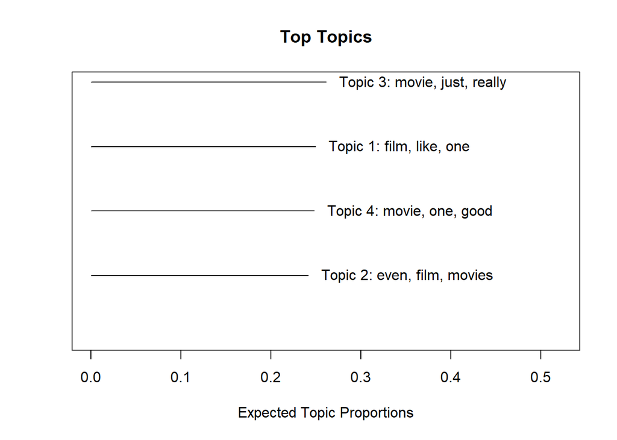

```r
plot(lda4)
```

Utilizando as nuvens de palavras + as palavras apresentadas no *summary*;

- Tópico 1: **enredo** Palavras usadas: “funny”, “original”, “hollywood”, “real”, “characters”…
- Tópico 2: **comparação** Palavras usadas: “better”, “even”, “work”, “look”, “quite”…
- Tópico 3: **reações/julgamento** Palavras usadas: “bad”, “stupid”, “love”, “think”, “really”…
- Tópico 4: **qualidade/característica** Palavras usadas: “good”, “actually”, “actors”, “old”, “pretty”, “director”, “time”…

### 1b) Indique a probabilidade das palavras para cada um dos tópicos, faça um gráfico com as 10 palavras mais prováveis por tópico.

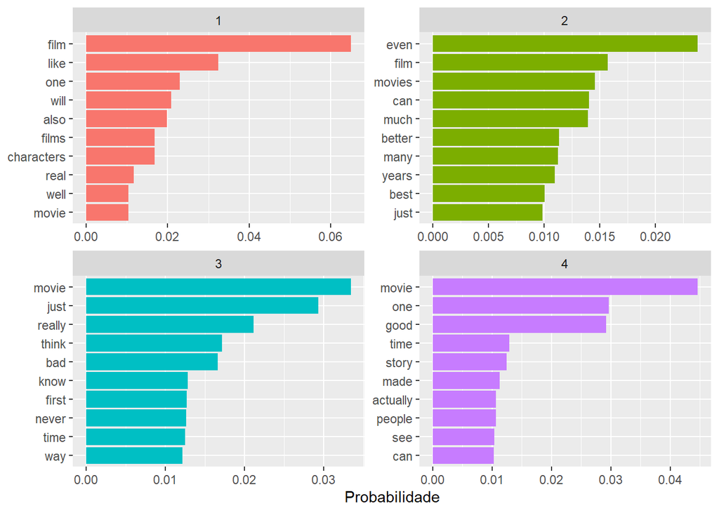

```r
# Converter o modelo stm para formato tidy
tidy_lda <- tidy(lda4)

# Filtrar as top 10 palavras por tópico
top_words <- tidy_lda %>%
  group_by(topic) %>%
  slice_max(beta, n = 10) %>%
  ungroup()

# Gráfico
ggplot(top_words, aes(x = reorder_within(term, beta, topic), y = beta, fill = factor(topic))) +
  geom_col(show.legend = FALSE) +
  facet_wrap(~topic, scales = "free") +
  coord_flip() +
  scale_x_reordered() +
  labs(x = NULL, y = "Probabilidade")
```

### 1c) Qual o tópico mais provável para cada documento? Sorteie 3 documentos e avalie essas probabilidades, o tópico mais provável faz sentido dado a divisão da letra a)?

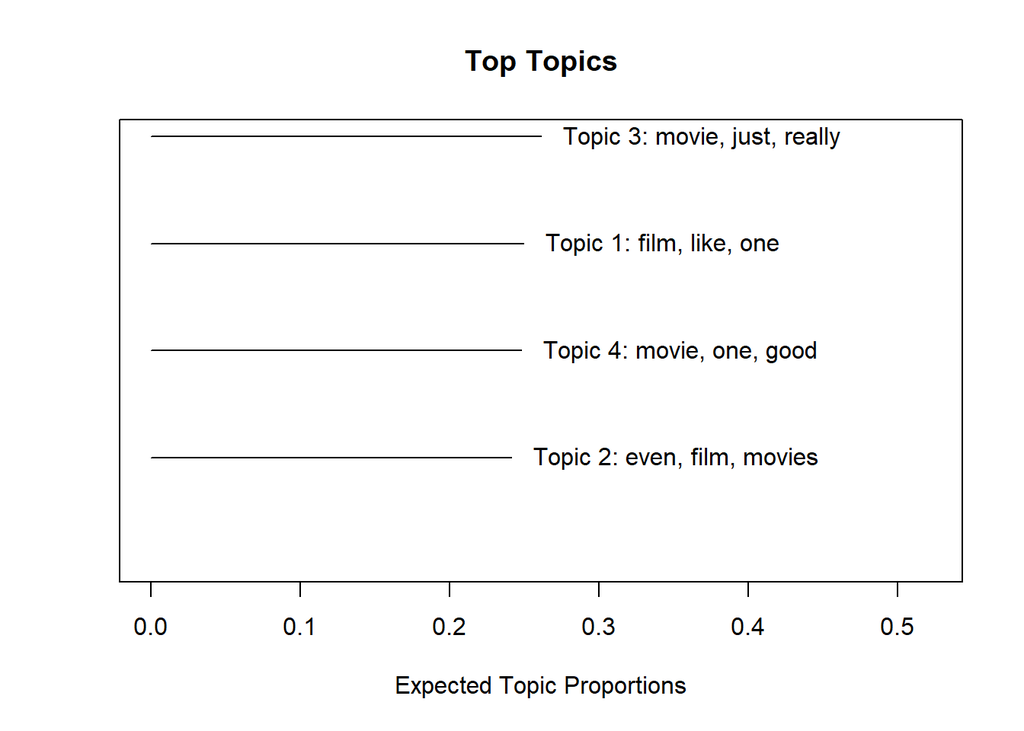

```r
set.seed(42)

doc_topics <- tidy(lda4, matrix = "gamma")

plot(lda4)
```

```r
docs_samp <- sample(1:nrow(lda4$theta), 3)

prob <- lda4$theta[docs_samp, ]
top  <- apply(prob, 1, which.max)

resum <- data.frame(
  doc      = docs_samp,
  prob_top = top,
  ps = apply(prob, 1, function(x) paste(x, collapse = "; "))
)

resum
```

```
##   doc prob_top
## 1 561        4
## 2 997        2
## 3 321        3
##                                                                           ps
## 1 0.221899428996022; 0.204346477664232; 0.272797740589005; 0.300956352750741
## 2  0.232177933681114; 0.26706214376591; 0.264931235338064; 0.235828687214912
## 3 0.248804151351157; 0.243489061061385; 0.268277618934485; 0.239429168652973
```

```r
imdb$review[resum$doc]
```

```
## [1] "This film is in no way entertainment but more of a look deep into the depths of the darkest side of human behaviour. Loosely linking a half a dozen stories of the worst kind of depravities, perverted sex, greed, violence and intolerance. All the action is played out over a few very hot and s…
## [2] "But this movie was a bore. The history part was fine but the musical part was not. Not one song I cared about and no soundtrack to be heard.<br /><br />If Sweet Jesus\" was suppose to be comic relief it never work. If John Adams was suppose to be the obnoxious annoying one, the rest of them …
## [3] "This movie is an amusing and utterly sarcastic view of pop culture and the producers thereof. I was impressed with the photography that consisted of vivid colors and spin doctored settings, especially when you think that this is Zukovic's first large scale attempt.<br /><br />One warning, do…
```

Considerando as palavras usadas e o fato de que os tópicos são de certa forma “genéricos” podemos dizer que faz sentido essa classificação, apesar de ser difícil a diferenciação entre tópicos.

### 1d) Faça um gráfico com as frequencias da distribuição dos tópicos mais prováveis por documento.

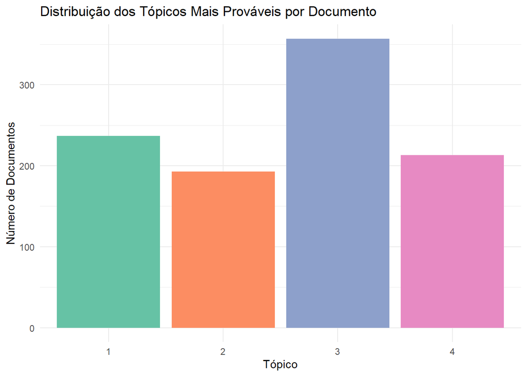

```r
topic_distribution <- doc_topics %>%
  group_by(document) %>%
  slice_max(gamma, n = 1) %>%
  ungroup()

ggplot(topic_distribution, aes(x = factor(topic), fill = factor(topic))) +
  geom_bar(stat = "count") +
  labs(
    x = "Tópico",
    y = "Número de Documentos",
    title = "Distribuição dos Tópicos Mais Prováveis por Documento",
    fill = "Tópico"
  ) +
  theme_minimal() +
  theme(legend.position = "none") +
  scale_fill_brewer(palette = "Set2")
```

## Questão 2

Altere o número de tópicos para `k = 6`. Refaça as análises da questão 1. Os temas ficaram mais claros ou mais difusos?

### 2a)

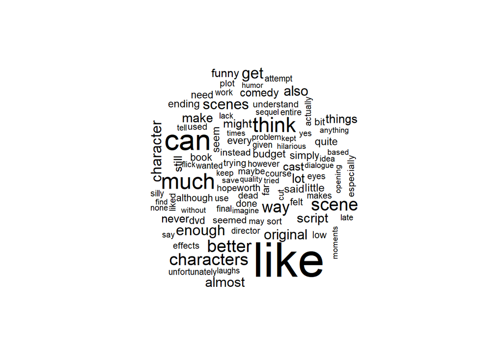

```r
dfm <- tidy(dtm) %>%
  cast_dfm(document = document,
           term = term,
           value = count)

lda6 <- stm(dfm,
            K = 6,
            verbose = FALSE,
            init.type = "LDA",
            seed = 42)

cloud(lda6, 1)
```

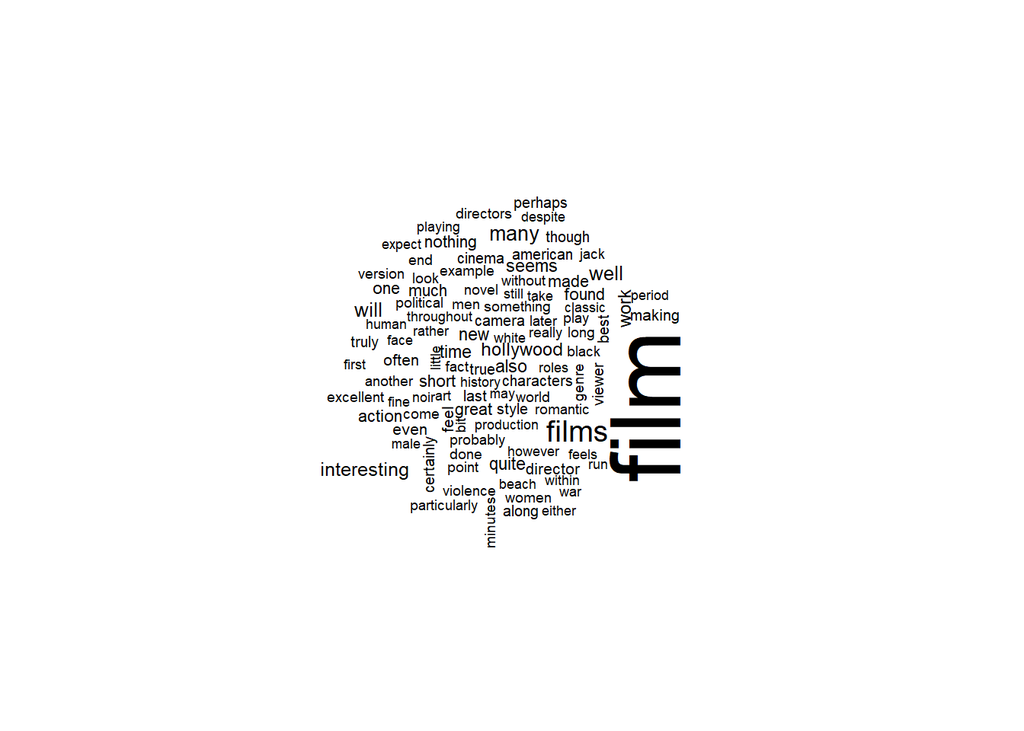

```r
cloud(lda6, 2)
```

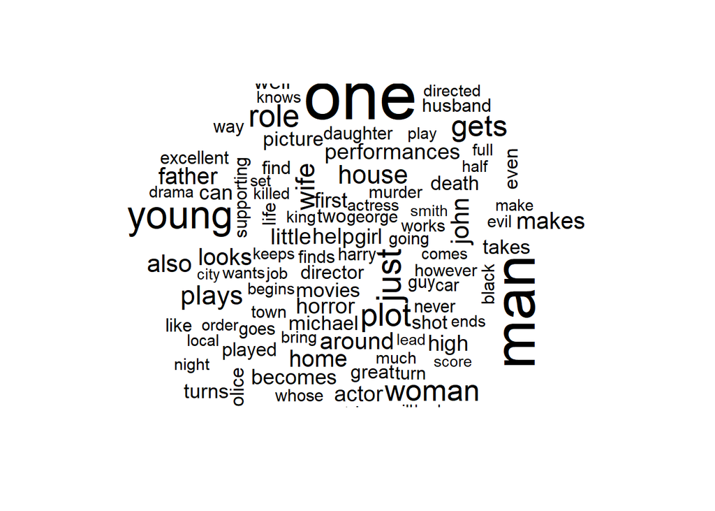

```r
cloud(lda6, 3)
```

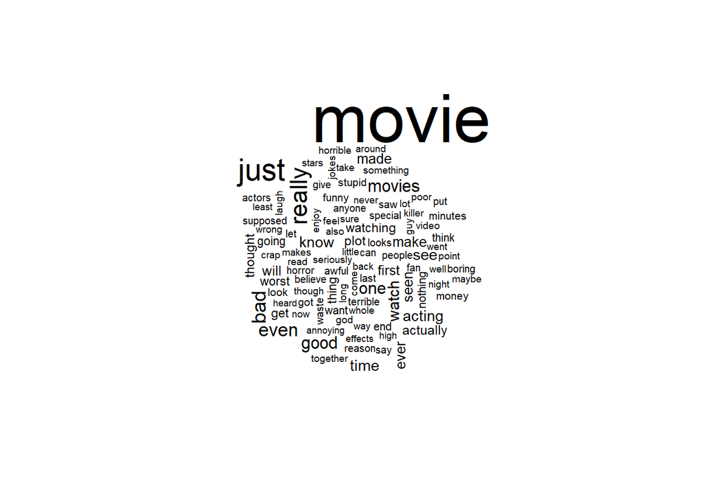

```r
cloud(lda6, 4)
```

```r
summary(lda6)
```

```
## A topic model with 6 topics, 1000 documents and a 1547 word dictionary.
```

```
## Topic 1 Top Words:
##       Highest Prob: like, can, much, think, scene, better, characters
##       FREX: budget, original, need, script, scene, almost, said
##       Lift: dreadful, gore, sequel, degree, opportunity, succeed, animation
##       Score: like, think, budget, funny, original, scene, better
## Topic 2 Top Words:
##       Highest Prob: film, films, many, will, well, interesting, work
##       FREX: film, short, cinema, films, novel, genre, jack
##       Lift: beach, broken, contrast, culture, drawn, featuring, foreign
##       Score: film, films, noir, style, beach, london, cinema
## Topic 3 Top Words:
##       Highest Prob: one, man, young, just, plot, performance, role
##       FREX: wife, plays, man, young, turns, picture, harry
##       Lift: begins, debut, dirty, fame, george, harry, local
##       Score: harry, man, young, wife, performance, joseph, father
## Topic 4 Top Words:
##       Highest Prob: movie, just, really, bad, even, movies, good
##       FREX: bad, movie, worst, stupid, supposed, awful, thought
##       Lift: agree, damn, fake, footage, gonna, horrible, lame
##       Score: movie, bad, worst, stupid, waste, watch, awful
## Topic 5 Top Words:
##       Highest Prob: one, love, show, years, time, great, best
##       FREX: show, series, love, episode, years, episodes, james
##       Lift: won, army, band, cable, dance, disney, episode
##       Score: show, season, series, episode, love, episodes, years
## Topic 6 Top Words:
##       Highest Prob: good, people, story, real, two, life, part
##       FREX: part, different, big, real, editing, etc, school
##       Lift: anime, aside, consider, documentary, ground, independent, literally
##       Score: people, family, two, life, part, school, good
```

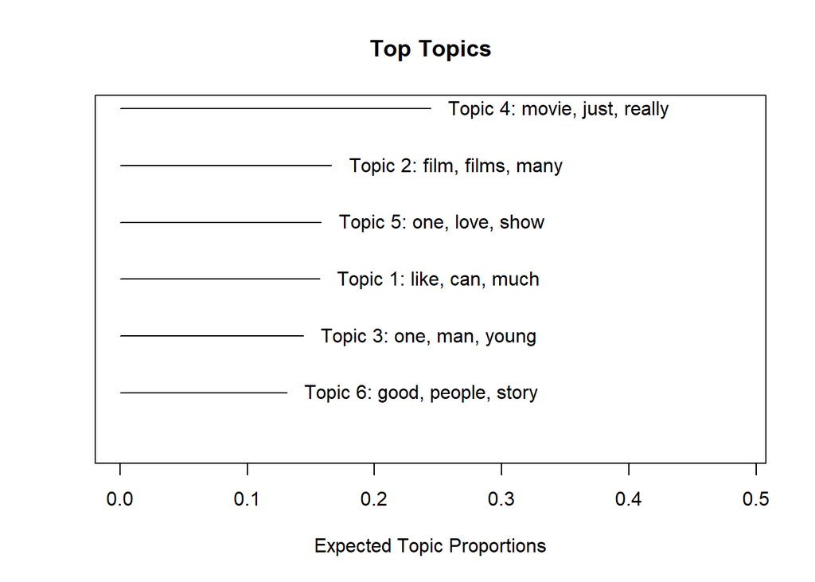

```r
plot(lda6)
```

### 2b)

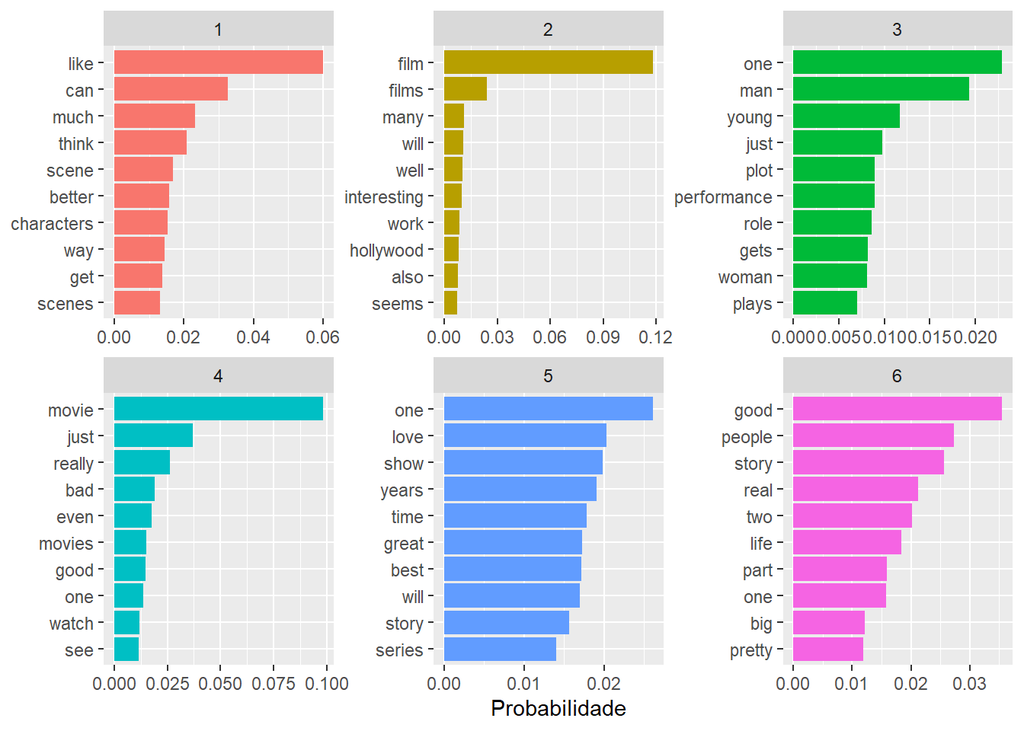

```r
# Converter o modelo stm para formato tidy
tidy_lda <- tidy(lda6)

# Filtrar as top 10 palavras por tópico
top_words <- tidy_lda %>%
  group_by(topic) %>%
  slice_max(beta, n = 10) %>%
  ungroup()

# Gráfico
ggplot(top_words, aes(x = reorder_within(term, beta, topic), y = beta, fill = factor(topic))) +
  geom_col(show.legend = FALSE) +
  facet_wrap(~topic, scales = "free") +
  coord_flip() +
  scale_x_reordered() +
  labs(x = NULL, y = "Probabilidade")
```

### 2c)

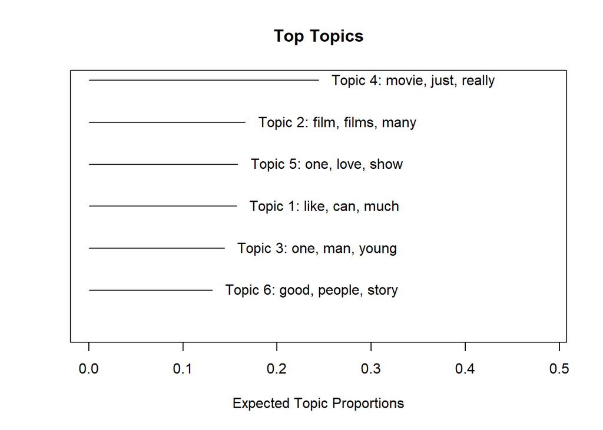

```r
set.seed(42)

doc_topics <- tidy(lda6, matrix = "gamma")

plot(lda6)
```

```r
docs_samp <- sample(1:nrow(lda6$theta), 3)

prob <- lda6$theta[docs_samp, ]
top  <- apply(prob, 1, which.max)

resum <- data.frame(
  doc      = docs_samp,
  prob_top = top,
  ps = apply(prob, 1, function(x) paste(x, collapse = "; "))
)

resum
```

```
##   doc prob_top
## 1 561        5
## 2 997        1
## 3 321        4
##                                                                                                                  ps
## 1 0.157038364406048; 0.185450345523385; 0.0955621653822662; 0.195877184797612; 0.242343941509028; 0.123727998381662
## 2  0.253803982450004; 0.207943733111397; 0.0783179053221488; 0.142728658140773; 0.18486867394343; 0.132337047032248
## 3   0.19135039177122; 0.148562504790039; 0.201154382289448; 0.237723699254574; 0.116164274668765; 0.105044747225953
```

### 2d)

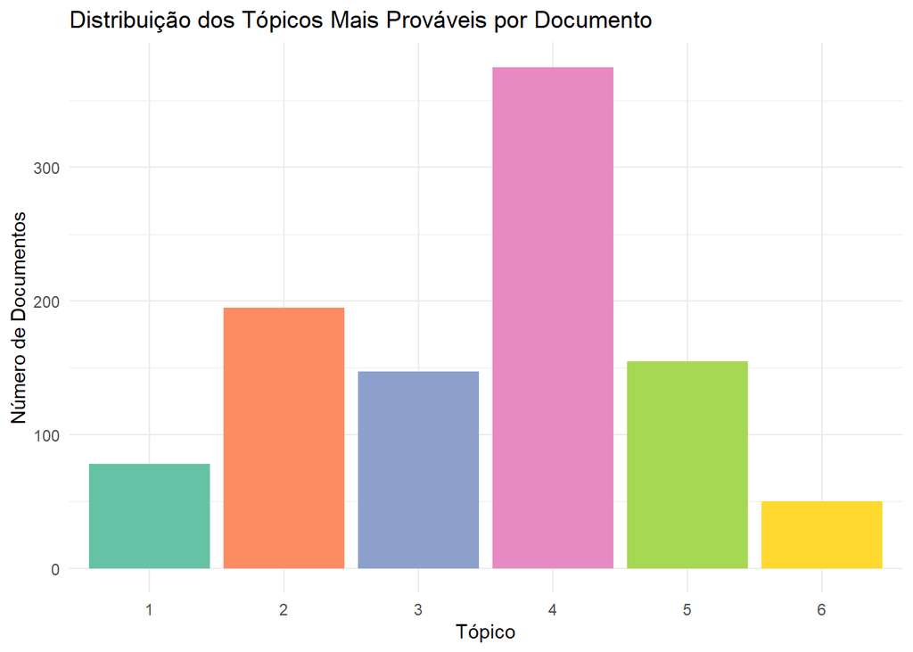

```r
topic_distribution <- doc_topics %>%
  group_by(document) %>%
  slice_max(gamma, n = 1) %>%
  ungroup()

ggplot(topic_distribution, aes(x = factor(topic), fill = factor(topic))) +
  geom_bar(stat = "count") +
  labs(
    x = "Tópico",
    y = "Número de Documentos",
    title = "Distribuição dos Tópicos Mais Prováveis por Documento",
    fill = "Tópico"
  ) +
  theme_minimal() +
  theme(legend.position = "none") +
  scale_fill_brewer(palette = "Set2")
```

### Conclusão sobre os tópicos;

A separação proporcionou mais clareza em relação a k = 4. Como podemos ver no item c a probabilidade não ficou tão equilibrada entre todos os tópicos como anteriormente. Os tópicos também estão menos “genéricos”.

## Questão 3

Altere o número de tópicos para `k = 2`. Os temas ficaram mais claros ou mais difusos?

### 3a)

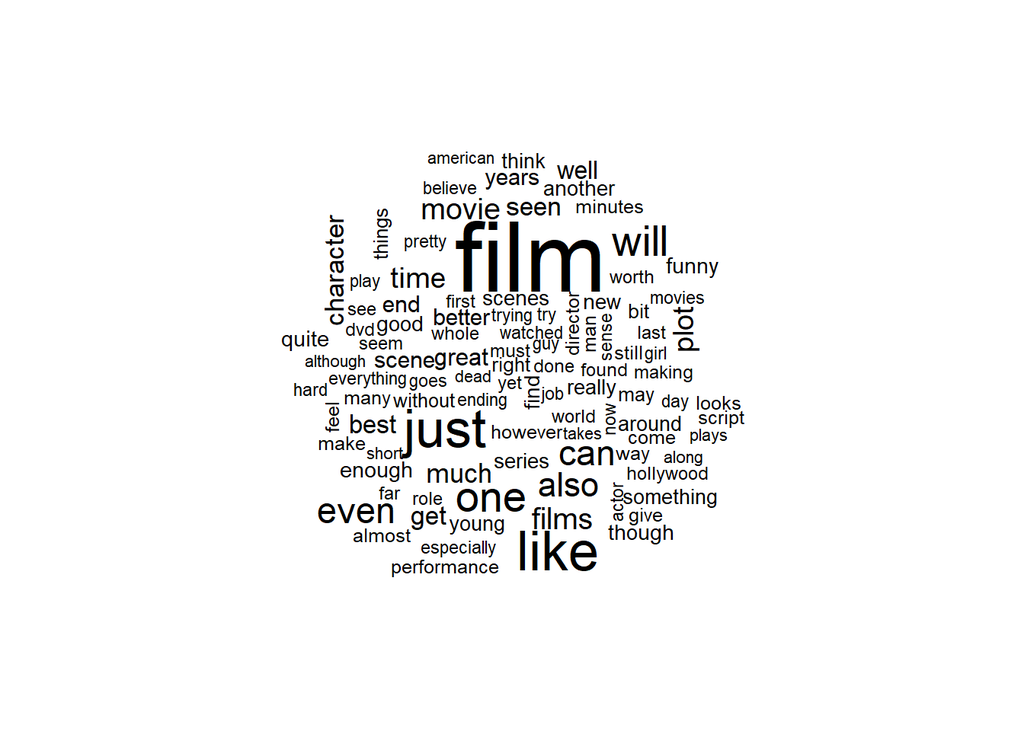

```r
dfm <- tidy(dtm) %>%
  cast_dfm(document = document,
           term = term,
           value = count)

lda2 <- stm(dfm,
            K = 2,
            verbose = FALSE,
            init.type = "LDA",
            seed = 42)

cloud(lda2, 1)
```

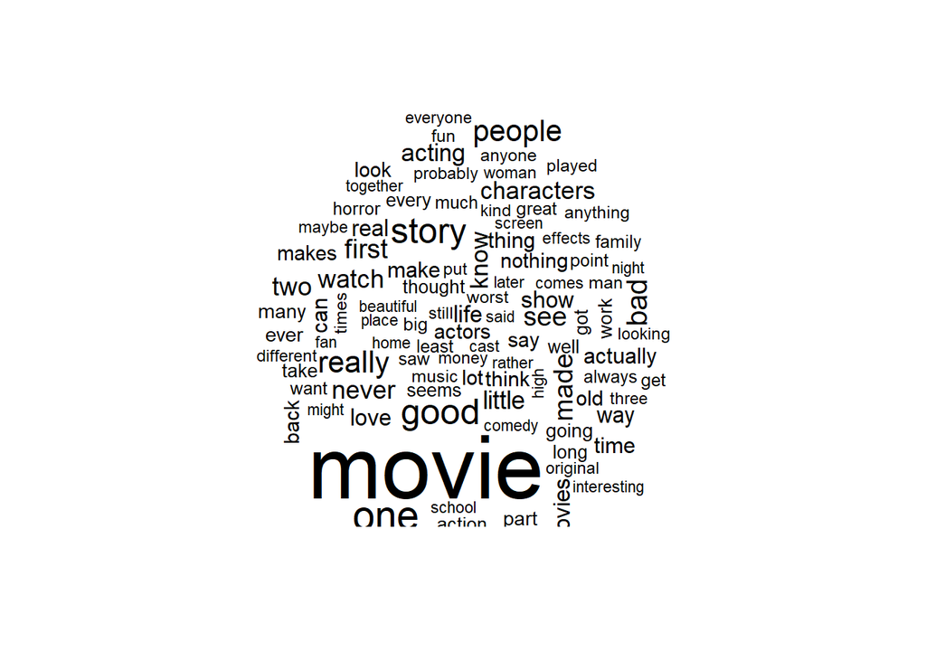

```r
cloud(lda2, 2)
```

```r
summary(lda2)
```

```
## A topic model with 2 topics, 1000 documents and a 1547 word dictionary.
```

```
## Topic 1 Top Words:
##       Highest Prob: film, like, just, will, one, even, can
##       FREX: will, also, films, plot, character, best, scene
##       Lift: will, films, also, plot, character, best, enough
##       Score: will, film, also, films, plot, character, best
## Topic 2 Top Words:
##       Highest Prob: movie, one, good, story, really, people, bad
##       FREX: people, bad, made, two, acting, show, little
##       Lift: bad, people, show, acting, made, love, two
##       Score: people, bad, made, two, little, acting, life
```

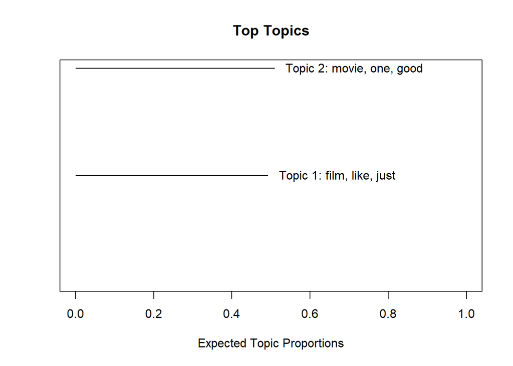

```r
plot(lda2)
```

### 3b)

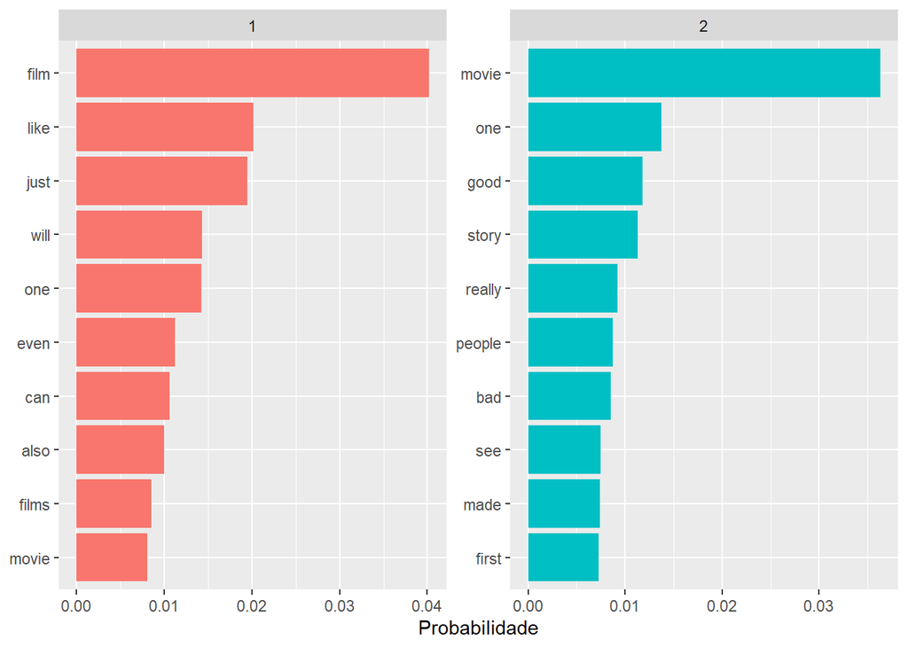

```r
# Converter o modelo stm para formato tidy
tidy_lda <- tidy(lda2)

# Filtrar as top 10 palavras por tópico
top_words <- tidy_lda %>%
  group_by(topic) %>%
  slice_max(beta, n = 10) %>%
  ungroup()

# Gráfico
ggplot(top_words, aes(x = reorder_within(term, beta, topic), y = beta, fill = factor(topic))) +
  geom_col(show.legend = FALSE) +
  facet_wrap(~topic, scales = "free") +
  coord_flip() +
  scale_x_reordered() +
  labs(x = NULL, y = "Probabilidade")
```

### 3c)

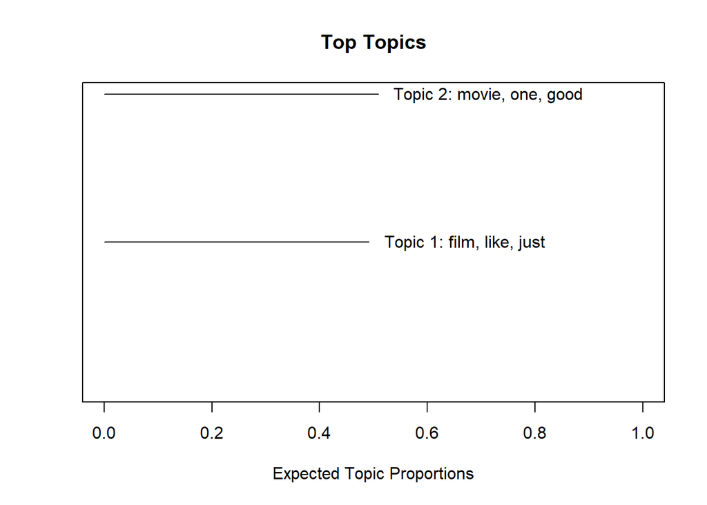

```r
set.seed(42)

doc_topics <- tidy(lda2, matrix = "gamma")

plot(lda2)
```

```r
docs_samp <- sample(1:nrow(lda2$theta), 3)

prob <- lda2$theta[docs_samp, ]
top  <- apply(prob, 1, which.max)

resum <- data.frame(
  doc      = docs_samp,
  prob_top = top,
  ps = apply(prob, 1, function(x) paste(x, collapse = "; "))
)

resum
```

```
##   doc prob_top                                   ps
## 1 561        2 0.442156771182355; 0.557843228817645
## 2 997        2 0.438243437897514; 0.561756562102486
## 3 321        1 0.511500898013953; 0.488499101986047
```

### 3d)

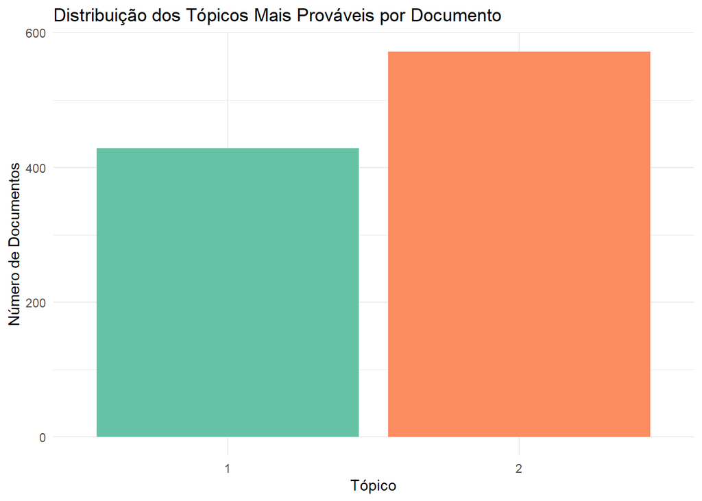

```r
topic_distribution <- doc_topics %>%
  group_by(document) %>%
  slice_max(gamma, n = 1) %>%
  ungroup()

ggplot(topic_distribution, aes(x = factor(topic), fill = factor(topic))) +
  geom_bar(stat = "count") +
  labs(
    x = "Tópico",
    y = "Número de Documentos",
    title = "Distribuição dos Tópicos Mais Prováveis por Documento",
    fill = "Tópico"
  ) +
  theme_minimal() +
  theme(legend.position = "none") +
  scale_fill_brewer(palette = "Set2")
```

### Conclusão sobre os tópicos;

Com apenas 2 tópicos podemos ver uma distinção entre eles mas é difícil defini-los. Os tópicos ficam mais genéricos e menos claros/objetivos.

## Questão 4

Calcule a perplexidade para k=2, k=4 e k=6. Compare os resultados, qual modelo é o melhor considerando essa métrica?

```r
perp <- data.frame(K = c(), Perplexidade = c())

for (k in c(2, 4, 6)) {
  lda_model <- LDA(dtm, k = k, control = list(seed = 42))
  perplex <- perplexity(lda_model, dtm)
  perp <- rbind(perp, data.frame(K = k, Perplexidade = perplex))
}

perp
```

```
##   K Perplexidade
## 1 2     823.5350
## 2 4     824.4519
## 3 6     825.1728
```

Por essa métrica temos uma diferença muito pequena entre os modelos, mas o modelo com k = 2 é ligeiramente melhor, já que para perplexidade quanto menor melhor.

## Questão 5

Como esse tipo de análise pode ajudar empresas que coletam grandes volumes de texto (ex: SAC, redes sociais)?

Dependendo do ramo da empresa, essa análise pode contribuir muito com a atividade fim, por exemplo: empresas de SAC podem identificar problemas/reclamações + recorrentes, automatizar respostas, captar melhor o feedbacks recebidos… Redes sociais podem determinar temas relevantes, segmentar usuários, melhorar recomendações/publicidades…